# S&P 500 Companies data set

A short analysis on a dataset containing a list of all companies in the S&P 500, all stocks, as well as associated key financials (price, market capitalization, earnings, price/earnings ratio, etc.).

The following code imports the csv as a pandas data fram and then proceeds to show the first 5 rows of the data frame.

```python
import pandas as pd
df = pd.read_csv("constituents-financials_csv.csv")
df.head()
```

|  | Symbol | Name | Sector | Price | Price/Earnings | Dividend Yield | Earnings/Share | 52 Week Low | 52 Week High | Market Cap | EBITDA | Price/Sales | Price/Book | SEC Filings |
| --- | --- | --- | --- | --- | --- | --- | --- | --- | --- | --- | --- | --- | --- | --- |
| 0 | MMM | 3M Company | Industrials | 222.89 | 24.31 | 2.332862 | 7.92 | 259.77 | 175.490 | 138721055226 | 9.048000e+09 | 4.390271 | 11.34 | http://www.sec.gov/cgi-bin/browse-edgar?action... |
| 1 | AOS | A.O. Smith Corp | Industrials | 60.24 | 27.76 | 1.147959 | 1.70 | 68.39 | 48.925 | 10783419933 | 6.010000e+08 | 3.575483 | 6.35 | http://www.sec.gov/cgi-bin/browse-edgar?action... |
| 2 | ABT | Abbott Laboratories | Health Care | 56.27 | 22.51 | 1.908982 | 0.26 | 64.60 | 42.280 | 102121042306 | 5.744000e+09 | 3.740480 | 3.19 | http://www.sec.gov/cgi-bin/browse-edgar?action... |
| 3 | ABBV | AbbVie Inc. | Health Care | 108.48 | 19.41 | 2.499560 | 3.29 | 125.86 | 60.050 | 181386347059 | 1.031000e+10 | 6.291571 | 26.14 | http://www.sec.gov/cgi-bin/browse-edgar?action... |
| 4 | ACN | Accenture plc | Information Technology | 150.51 | 25.47 | 1.714470 | 5.44 | 162.60 | 114.820 | 98765855553 | 5.643228e+09 | 2.604117 | 10.62 | http://www.sec.gov/cgi-bin/browse-edgar?action... |

The following code represents the shape of the data frame (number of rows, number of columns)

```python
df.shape
```

```
(505, 14)
```

The following code represents the info of the data frame (data type, column name, null count, memory usage, etc.)

```python
df.info()
```

```
<class 'pandas.core.frame.DataFrame'>
RangeIndex: 505 entries, 0 to 504
Data columns (total 14 columns):
 #   Column          Non-Null Count  Dtype
---  ------          --------------  -----
 0   Symbol          505 non-null    object
 1   Name            505 non-null    object
 2   Sector          505 non-null    object
 3   Price           505 non-null    float64
 4   Price/Earnings  503 non-null    float64
 5   Dividend Yield  505 non-null    float64
 6   Earnings/Share  505 non-null    float64
 7   52 Week Low     505 non-null    float64
 8   52 Week High    505 non-null    float64
 9   Market Cap      505 non-null    int64
 10  EBITDA          505 non-null    float64
 11  Price/Sales     505 non-null    float64
 12  Price/Book      497 non-null    float64
 13  SEC Filings     505 non-null    object
dtypes: float64(9), int64(1), object(4)
memory usage: 55.4+ KB
```

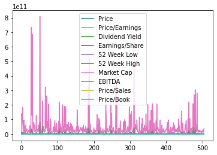

```python
df.plot()
```

The following code counts the number of unique values and the number of times a unique value appears in the 'Name' column.

```python
df['Name'].value_counts()
```

```
Becton Dickinson          1
NetApp                    1
Zions Bancorp             1
Adobe Systems Inc         1
Verizon Communications    1
                         ..
United Parcel Service     1
Delta Air Lines Inc.      1
Qorvo                     1
HCA Holdings              1
Nasdaq, Inc.              1
Name: Name, Length: 505, dtype: int64
```

The following code creates a new data frame based of of the old data frame execpt it only includes the values where the Name of the company starts with the letter A. The code then proceeds to output the last 5 rows the this new data frame.

```python
df_new = df[[x[0] == 'A' for x in df['Name']]]
df_new.tail()
```

|  | Symbol | Name | Sector | Price | Price/Earnings | Dividend Yield | Earnings/Share | 52 Week Low | 52 Week High | Market Cap | EBITDA | Price/Sales | Price/Book | SEC Filings |
| --- | --- | --- | --- | --- | --- | --- | --- | --- | --- | --- | --- | --- | --- | --- |
| 59 | ADSK | Autodesk Inc | Information Technology | 104.81 | -77.07 | 0.000000 | -2.61 | 131.10 | 81.750 | 24348294504 | -3.781000e+08 | 16.506820 | 224.13 | http://www.sec.gov/cgi-bin/browse-edgar?action... |
| 60 | ADP | Automatic Data Processing | Information Technology | 108.25 | 29.34 | 2.219091 | 3.85 | 125.24 | 95.500 | 50337702249 | 2.767400e+09 | 4.048329 | 12.86 | http://www.sec.gov/cgi-bin/browse-edgar?action... |
| 61 | AZO | AutoZone Inc | Consumer Discretionary | 718.57 | 16.31 | 0.000000 | 44.09 | 797.89 | 491.130 | 19922021415 | 2.347304e+09 | 1.851043 | 136.23 | http://www.sec.gov/cgi-bin/browse-edgar?action... |
| 62 | AVB | AvalonBay Communities, Inc. | Real Estate | 154.94 | 17.97 | 3.714936 | 6.36 | 199.52 | 156.010 | 21856547430 | 1.331579e+09 | 10.251216 | 2.12 | http://www.sec.gov/cgi-bin/browse-edgar?action... |
| 63 | AVY | Avery Dennison Corp | Materials | 110.77 | 22.11 | 1.568217 | 3.11 | 123.67 | 78.471 | 10104814319 | 8.312000e+08 | 1.520650 | 8.83 | http://www.sec.gov/cgi-bin/browse-edgar?action... |